# R Notebook

BCubed

```r
cluster_assignments <- c(pam.result$cluster)

set.seed(7)

# Specify the number of rows you want to sample
num_rows <- 100

# Use sample with the specified seed
idx <- sample(1:dim(Hobby_proc)[1], num_rows)

# Select the sampled rows from Hobby_proc
Hobby_Data4 <- Hobby_proc[idx, ]

# Create a data frame with cluster assignments and ground truth labels
dataset <- data.frame(cluster = cluster_assignments, label = ground_truth_labels)

# Calculate BCubed precision and recall
calculate_bcubed_metrics <- function(dataset) {
  n <- nrow(dataset)
  precision_sum <- 0
  recall_sum <- 0

  for (i in 1:n) {
    cluster <- dataset$cluster[i]
    label <- dataset$label[i]

    # Count the number of items from the same category in its cluster
    same_category <- sum(dataset$label[dataset$cluster == cluster] == label)

    # Count the number of items in its cluster
    same_cluster <- sum(dataset$cluster == cluster)

    # Count the number of items in its category
    total_same_category <- sum(dataset$label == label)

    # Calculate precision and recall
    precision_sum <- precision_sum + same_category / same_cluster
    recall_sum <- recall_sum + same_category / total_same_category
  }
  # End loop

  # Calculate average precision and recall
  precision <- precision_sum / n
  recall <- recall_sum / n

  return(list(precision = precision, recall = recall))
}

# Calculate BCubed precision and recall
metrics <- calculate_bcubed_metrics(dataset)
precision <- metrics$precision
recall <- metrics$recall

# Print the results
cat("BCubed Precision= ", precision, "AND BCubed Recall= ", recall, "\n")
```

```
BCubed Precision=  0.05053585 AND BCubed Recall=  0.4100765
```

The results indicate challenges in clustering performance. The low precision suggests a significant rate of misclassification, while the relatively low recall indicates that some instances within the same group are missed or incorrectly assigned to other clusters. These results highlight limitations in accurately capturing the data’s underlying structure.

**group into k=2 clusters**

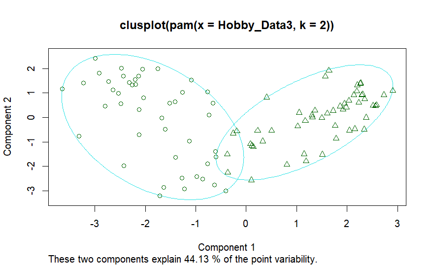

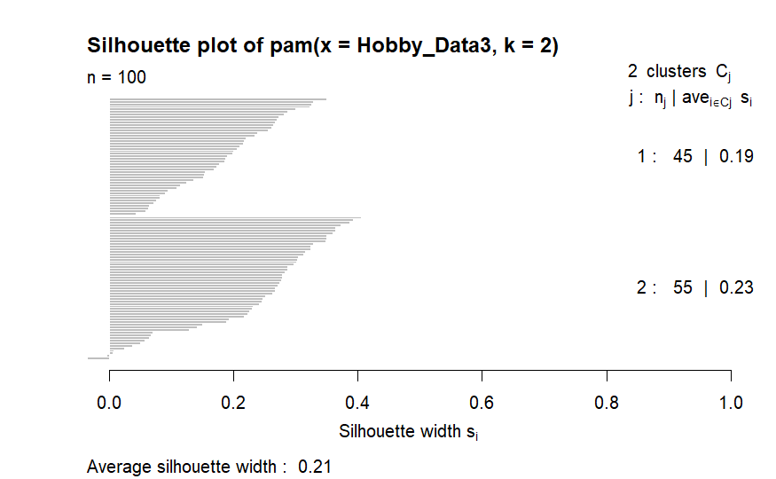

```r
set.seed(7)

# Specify the number of rows you want to sample
num_rows <- 100

# Use sample with the specified seed
idx <- sample(1:dim(Hobby_Data2)[1], num_rows)

Hobby_Data3 <- Hobby_Data2[idx, ]

pam.result <- pam(Hobby_Data3,2)
#Show the silhoutee plot of PAM AND clusters
plot(pam.result)
```

wws

```r
# Extract the clusinfo component
clusinfo <- pam.result$clusinfo

# Calculate the total within-cluster sum of squares
tot_withinss <- sum(clusinfo[, "size"] * clusinfo[, "av_diss"]^2)

# Print the result
print(tot_withinss)
```

```
[1] 1059.6
```

An overlap between clusters implies that there is ambiguity in the assignment of data points to clusters, and the clusters may not be sufficiently distinct. In such cases, it might be needed to reconsider the number of clusters since the goal is to find a balance, but too few clusters result in oversimplification, as indicated by the observed overlap, and it is evident that forming only two clusters may not be sufficient to represent the inherent structure of the dataset.

BCubed

```r
cluster_assignments <- c(pam.result$cluster)

set.seed(7)

# Specify the number of rows you want to sample
num_rows <- 100

# Use sample with the specified seed
idx <- sample(1:dim(Hobby_proc)[1], num_rows)

# Select the sampled rows from Hobby_proc
Hobby_Data4 <- Hobby_proc[idx, ]

# Create a data frame with cluster assignments and ground truth labels
dataset <- data.frame(cluster = cluster_assignments, label = ground_truth_labels)

# Calculate BCubed precision and recall
calculate_bcubed_metrics <- function(dataset) {
  n <- nrow(dataset)
  precision_sum <- 0
  recall_sum <- 0

  for (i in 1:n) {
    cluster <- dataset$cluster[i]
    label <- dataset$label[i]

    # Count the number of items from the same category in its cluster
    same_category <- sum(dataset$label[dataset$cluster == cluster] == label)

    # Count the number of items in its cluster
    same_cluster <- sum(dataset$cluster == cluster)

    # Count the number of items in its category
    total_same_category <- sum(dataset$label == label)

    # Calculate precision and recall
    precision_sum <- precision_sum + same_category / same_cluster
    recall_sum <- recall_sum + same_category / total_same_category
  }
  # End loop

  # Calculate average precision and recall
  precision <- precision_sum / n
  recall <- recall_sum / n

  return(list(precision = precision, recall = recall))
}

# Calculate BCubed precision and recall
metrics <- calculate_bcubed_metrics(dataset)
precision <- metrics$precision
recall <- metrics$recall

# Print the results
cat("BCubed Precision= ", precision, "AND BCubed Recall= ", recall, "\n")
```

```
BCubed Precision=  0.04319837 AND BCubed Recall=  0.6252147
```

The relatively high recall could be influenced by the specific choice of two clusters since it is sensitive to the number of clusters. In the context of a two-cluster solution, the recall score reflects how well the algorithm groups data points from the same class into one of the two identified clusters. Recall suggests that a significant portion of data points from the same ground truth class are indeed grouped together in one of the two clusters. However, it’s important to note that the low precision score (0.0432) indicates a lack of homogeneity within the identified clusters, implying that the clusters contain a mix of data points from different ground truth classes.

**AS A Summary For clustring** Silhouette analysis measures how similar an object is to its own cluster (cohesion) compared to other clusters (separation). The silhouette width ranges from -1 to 1, where a high value indicates that the object is well matched to its own cluster and poorly matched to neighboring clusters. In our project we did clusters for k=3, k=4, and k=2 since its have higher average silhouette then other number.

For k=3, the average silhouette width is 0.22. For k=4, the average silhouette width is 0.19. For k=2, the average silhouette width is 0.21.

A higher average silhouette width generally indicates better-defined clusters. So, in this case, k=3 has the highest average silhouette width.

BCubed is a clustering evaluation metric that considers both precision and recall. Precision measures the accuracy of the positive predictions, while recall measures the coverage of the actual positive instances.

For k=3, BBCubed Precision = 0.0488 BCubed Recall = 0.4932. For k=4,BCubed Precision = 0.0505 BCubed Recall = 0.4101. For k=2, BCubedPrecision = 0.0432 BCubed Recall = 0.6252.

These metrics measure how well the clustering aligns with the ground truth. Higher precision indicates fewer false positives, and higher recall indicates fewer false negatives. Here, k=2 has the highest recall (0.6252), but k=3 has a reasonable balance between precision and recall.

In conclusion, k=3 seems to be a reasonable choice. It has a good silhouette width, and its BCubed Precision and Recall values strike a balance.

**-------------------------------------------------------------------------------------------------------------------**

**6.Evaluation and Comparison**

**#1#Classification with comparison criteria**

|  | 90%/10% | 90%/10% | 90%/10% | 80%/20% | 80%/20% | 80%/20% | 70%/30% | 70%/30% | 70%/30% |
| --- | --- | --- | --- | --- | --- | --- | --- | --- | --- |
|  | IG | IG ratio | Gini Index | IG | IG ratio | Gini Index | IG | IG ratio | Gini Index |
| **Accuracy** | 0.872 | 0.8944 | 0.91875 | 0.905 | 0.888 | 0.906 | 0.893 | 0.8939 | 0.911 |
| **precision** | 0.856 | 0.892 | 0.91850 | 0.898 | 0.881 | 0.905 | 0.887 | 0.890 | 0.909 |
| **sensitiviy** | 0.856 | 0.891 | 0.91927 | 0.898 | 0.890 | 0.909 | 0.887 | 0.902 | 0.912 |
| **specificiy** | 0.919 | 0.945 | 0.9578 | 0.937 | 0.943 | 0.952 | 0.929 | 0.947 | 0.954 |

**#1#Clustering with comparison criteria**

|  | k = 2 | k = 3(BEST) | k = 4 |
| --- | --- | --- | --- |
| **Average Silhouette width** | 0.21 | 0.22 | 0.19 |
| **total within-cluster sum of square** | 1059.6 | 833.5585 | 762.8895 |
| **BCubed precision** | 0.0432 | 0.0488 | 0.0505 |
| **BCubed recall** | 0.6252 | 0.4932 | 0.4101 |
| **Visualization** | - | - | - |

**-note the Visualization In the implementaion of clustering above.-**

**Comparison of Classification and Clustering**

Classification is better than clustering for our data set because our problem involves predicting kids’ hobbies based on specific attributes, and classification models are designed for precisely this kind of task. In contrast, clustering is useful for discovering natural groupings but doesn’t necessarily assign them to predefined categories. Additionally, clustering might create groups that don’t directly correspond to the desired hobby categories, making interpretation and application more challenging in this context. Hence, the structured nature of classification, where the model is trained on labeled data to predict specific outcomes, makes it more appropriate for our task.

The nature of the data types, which include a majority of Boolean and ordinal variables in our dataset influenced the preference for classification over clustering, since classification models, particularly decision trees, are adept at handling these data types. On the other hand, cluster's application might be less straightforward when dealing with categorical and ordinal variables, especially if the goal is to predict predefined categories. making classification more appropriate for our dataset compared to clustering, which may not align with the structured prediction task in our case.

The observation of clusters being close to each other when plotted using PAM (Partitioning Around Medoids) while achieving high accuracy in the classification model does influence the preference for classification over clustering. The close proximity and overlap in clusters suggest that the clustering algorithm may not effectively separate the data points based on the given attributes. On the other hand, the high accuracy of the classification model indicates that the chosen classification approach, particularly decision tree models, is successful in accurately predicting the hobby for each data point. This performance difference reinforces the suitability of classification for our dataset, where the goal is to precisely assign specific labels to each observation based on its attributes, and clustering may not provide the necessary separation for effective prediction.

**-------------------------------------------------------------------------------------------------------------------**

**7.Findings**

**7.1: Classification Comparision:**

In the classification task, the evaluation of 36 metrics revealed distinctive performance patterns across various criteria:

1. Accuracy:

Gini 90-10 had the highest accuracy at 91.88%, closely followed by Gini 70-30 at 91.06%.

Information Gain 80-20 also displayed strong accuracy at 90.57%, and Gini 80-20 had an accuracy of 90.62%.

Information Gain 70-30 and Gini 80-20 closely followed with accuracies around 89.32% and 90.62% respectively.

Information Gain 90-10 displayed a lower accuracy at 87.21%.

2. Sensitivity:

Ratio models followed with sensitivity levels around 89.15% to 90.25%.

Information Gain models demonstrated slightly lower sensitivity, ranging from 85.66% (Information Gain 90-10) to 89.83% (Information Gain 80-20).

3. Specificity:

Gini models showcased strong specificity, reaching from 95.15% (Gini 80-20) to 95.79% (Gini 90-10).

Ratio models exhibited specificity between 94.26% (Ratio 80-20) and 94.66% (Ratio 70-30).

Information Gain models displayed specificity levels around 91.91% (Information Gain 90-10) to 93.78% (Information Gain 80-20).

4. Precision:

Gini models maintained high precision, ranging from 90.46% (Gini 80-20) to 91.85% (Gini 90-10).

Ratio models demonstrated precision between 88.11% (Ratio 80-20) and 89.19% (Ratio 90-10).

Information Gain models exhibited precision around 85.66% (Information Gain 90-10) to 89.83% (Information Gain 80-20).

Overall, Gini models consistently showcased strong performance across most metrics, especially in sensitivity and specificity, followed closely by Ratio models. Information Gain models, while competitive in accuracy, displayed slightly lower sensitivity and specificity compared to Gini and Ratio models.

**Analyzing and Selecting the Best Trees from Each Method**

1. Gini Index:

Best Tree: Gini 90-10

- Accuracy: 91.88%
- Sensitivity: 91.93%
- Specificity: 95.79%
- Precision: 91.85%

Explanation:

The Gini 90-10 tree outperforms others, providing the highest accuracy and well-balanced sensitivity and specificity. This tree exhibits superior predictive power, making it an optimal choice for accurately categorizing children’s hobbies.

The most influential attributes in predicting hobbies within the Gini Index Decision Tree (90/10) are engagement in sports activities (‘Career_sprt’), involvement in arts hobbies (‘Fant_arts’), and the level of arts activity (‘Time_art’).

Confusion Matrix for Gini 90-10:

Predicted Positive Predicted Negative

Actual Positive True Positive (91.93%) False Negative (8.07%)

Actual Negative False Positive (4.21%) True Negative (95.79%)

2. Ratio:

Best Tree: Ratio 90-10

Explanation: Among Ratio trees, the Ratio 90-10 tree stands out with competitive accuracy, sensitivity, and specificity. It strikes a balance between identifying positive cases and correctly predicting negative cases, making it a reliable choice for predicting children’s hobbies.

The primary attributes influencing hobby predictions in the Gain Ratio Decision Tree (90%/10%) are ‘Career_sprt,’ ‘Fant_arts,’ ‘Won_arts,’ ‘Olympiad_Participation,’ ‘Grasp_pow,’ ‘Time_art,’ and ‘Act_sprt.’

Confusion Matrix for Ratio 90-10:

Predicted Positive Predicted Negative

Actual Positive True Positive (89.15%) False Negative (10.85%)

3. Information Gain:

Best Tree: Information Gain 80-20

- Accuracy: 90.57%
- Sensitivity: 89.83%
- Specificity: 93.78%
- Precision: 89.83%

Explanation:

The Information Gain 80-20 tree exhibits strong accuracy and well-balanced sensitivity and specificity. It effectively utilizes information gain to predict children’s hobbies, making it a favorable choice within the Information Gain method.

The most influential attributes in predicting hobbies within the Information Gain Decision Tree (80/20) include engagement in sports activities (‘Career_sprt’), involvement in arts hobbies (‘Fant_arts’), and the level of arts activity (‘Time_art’).

Confusion Matrix for Information Gain 80-20:

Predicted Positive Predicted Negative

Actual Positive True Positive (89.83%) False Negative (10.17%)

Actual Negative False Positive (6.22%) True Negative (93.78%)

**Overall Analysis:**

- The Gini 90-10 tree excels in accuracy, sensitivity, and specificity within the Gini Index method.

- The Ratio 90-10 tree demonstrates competitive performance, particularly in accuracy and specificity within the Ratio method.

- The Information Gain 80-20 tree showcases strong accuracy and balanced sensitivity and specificity within the Information Gain method.

The selection of the best tree depends on specific priorities. If a well-balanced model is crucial, Gini 90-10 stands out. For a balanced Ratio model, Ratio 90-10 is favorable. Information Gain 80-20 offers strong accuracy and balance within the Information Gain method.

Best Tree Across All Methods:

Best Tree: Gini 90-10

Accuracy: 91.88%

Sensitivity: 91.93%

Specificity: 95.79%

Precision: 91.85%

The Gini 90-10 tree stands out as the best-performing tree across all methods, displaying superior accuracy, sensitivity, specificity, and precision. It excels in accurately predicting children’s hobbies, making it the optimal choice among the evaluated trees.

**7.2: the best partitioning method for clustering:**

According to our research and attempt to cluster using k-means algorithm we figured that it is not applicable to our data because it relies on the Euclidean distance metric to measure the similarity between data points. However, even after Encoding and its application to categorical data pose significant challenges. Categorical variables often lack a meaningful numerical representation; for instance, taking the mean of categories like the feature "favorite subject," aka "Fav_sub" (even after encoding), might not have any practical interpretation. And the distances calculated in the algorithm may not reflect the true dissimilarities between categorical values. The encoding process itself introduces artificial numerical relation that may mislead the algorithm. Moreover, k-means relies on the minimization of Euclidean distances, which might not accurately capture the dissimilarity structure in categorical data. Categorical variables inherently exhibit discrete and non-ordinal characteristics that are not well-suited for the continuous and linear assumptions of k-means. Alternative clustering techniques, specifically designed for categorical data, such as partitioning around medoids, are more appropriate for capturing the intrinsic patterns and relationships in categorical data sets. [7]

**7.3: Clustering Comparison:**

The chosen K holds significant implications for addressing the problem. In the context of guiding children towards suitable hobbies, it plays a pivotal role in optimizing the effectiveness of our model for parents in making informed choices. If K were set higher than 3, the categorization would lack the depth needed for insightful distinctions among preferences. On the other hand, if K were lower than 3, the model’s accuracy could be compromised, as one or more class labels may not be adequately defined within the clusters. This deficiency would adversely impact the precision of predictions, hindering the model’s ability to offer precise guidance to parents. By settling on K=3, we strike a balance that ensures meaningful and well-defined clusters, providing parents with a reliable tool to navigate and understand their child’s inclinations effectively, offering a comprehensive categorization that aligns with the inherent structure of the dataset.

**7.4: Clustering Interpretation:**

```r
# Create a temporary data frame for clustering results
clustered_data <- data.frame(Hobby_Data3, cluster = pam.result$clustering)

# Show all data points in each cluster
for (i in unique(pam.result$clustering)) {
  cat("Cluster", i, ":\n")
  print(clustered_data[clustered_data$cluster == i, -ncol(clustered_data)])
  cat("\n")
}
```

[output not shown]

|  | Olympiad_Participation | Scholarship | Fav_sub | Projects | Grasp_pow | Time_sprt | Career_sprt | Act_sprt | Fant_arts | Won_arts | Time_art | Predicted.Hobby |
| --- | --- | --- | --- | --- | --- | --- | --- | --- | --- | --- | --- | --- |
| 1 | -1.0269079 | -0.8458858 | -0.1064513 | 0.8535141 | 0.5161977 | -0.02502657 | 1.298148 | 0.8923899 | -0.8733494 | -0.8647707 | -0.1849875 | 1.3238737 |
| 2 | 0.9731889 | -0.8458858 | 1.7977780 | -1.1708949 | -0.4771106 | -0.02502657 | 1.298148 | 0.8923899 | -0.8733494 | 0.4042466 | -0.1849875 | 1.3238737 |
| 3 | -1.0269079 | 1.1814543 | -0.1064513 | 0.8535141 | -1.4704189 | 0.71696478 | 1.298148 | 0.8923899 | -0.8733494 | 1.6732638 | -0.1849875 | 1.3238737 |
| 8 | -1.0269079 | -0.8458858 | -0.1064513 | -1.1708949 | -0.4771106 | -0.02502657 | 1.298148 | 0.8923899 | -0.8733494 | -0.8647707 | 0.6047857 | 1.3238737 |
| 11 | -1.0269079 | 1.1814543 | -0.1064513 | 0.8535141 | 0.5161977 | -0.76701791 | 1.298148 | 0.8923899 | -0.8733494 | 1.6732638 | 1.3945589 | 1.3238737 |
| 14 | 0.9731889 | 1.1814543 | -1.0585660 | -1.1708949 | 0.5161977 | -0.76701791 | 1.298148 | 0.8923899 | -0.8733494 | 0.4042466 | 0.6047857 | 1.3238737 |
| 16 | -1.0269079 | -0.8458858 | 1.7977780 | 0.8535141 | -0.4771106 | 0.71696478 | 1.298148 | 0.8923899 | -0.8733494 | -0.8647707 | -0.1849875 | 1.3238737 |
| 20 | -1.0269079 | -0.8458858 | -0.1064513 | -1.1708949 | 0.5161977 | -0.02502657 | 1.298148 | 0.8923899 | -0.8733494 | -0.8647707 | -0.1849875 | 1.3238737 |
| 23 | -1.0269079 | -0.8458858 | -0.1064513 | 0.8535141 | -0.4771106 | 2.20094746 | 1.298148 | 0.8923899 | -0.8733494 | -0.8647707 | 1.3945589 | 1.3238737 |
| 25 | -1.0269079 | -0.8458858 | -0.1064513 | 0.8535141 | -0.4771106 | 2.20094746 | 1.298148 | 0.8923899 | -0.8733494 | -0.8647707 | -0.9747607 | 1.3238737 |

[output cut: 20 more lines]

```
Cluster 2 :
```

|  | Olympiad_Participation | Scholarship | Fav_sub | Projects | Grasp_pow | Time_sprt | Career_sprt | Act_sprt | Fant_arts | Won_arts | Time_art | Predicted.Hobby |
| --- | --- | --- | --- | --- | --- | --- | --- | --- | --- | --- | --- | --- |
| 4 | 0.9731889 | 1.1814543 | -1.0585660 | 0.8535141 | 1.5095060 | -0.02502657 | -0.769847 | 0.8923899 | -0.8733494 | 0.4042466 | -0.9747607 | -1.0207301 |
| 6 | 0.9731889 | 1.1814543 | -1.0585660 | 0.8535141 | 0.5161977 | -0.02502657 | -0.769847 | -1.1198865 | -0.8733494 | -0.8647707 | -0.9747607 | -1.0207301 |
| 7 | 0.9731889 | 1.1814543 | -0.1064513 | 0.8535141 | 0.5161977 | -0.02502657 | -0.769847 | 0.8923899 | 1.1443019 | 0.4042466 | -0.1849875 | -1.0207301 |
| 9 | 0.9731889 | 1.1814543 | -0.1064513 | 0.8535141 | 0.5161977 | -0.76701791 | 1.298148 | 0.8923899 | 1.1443019 | 0.4042466 | 2.1843322 | 0.1515718 |
| 12 | 0.9731889 | 1.1814543 | 1.7977780 | 0.8535141 | -1.4704189 | -0.76701791 | -0.769847 | -1.1198865 | -0.8733494 | -0.8647707 | -0.9747607 | -1.0207301 |
| 15 | 0.9731889 | 1.1814543 | 1.7977780 | 0.8535141 | -1.4704189 | -0.02502657 | -0.769847 | -1.1198865 | -0.8733494 | 1.6732638 | -0.1849875 | -1.0207301 |
| 17 | 0.9731889 | 1.1814543 | -1.0585660 | 0.8535141 | 0.5161977 | 0.71696478 | -0.769847 | -1.1198865 | -0.8733494 | -0.8647707 | 2.1843322 | -1.0207301 |
| 21 | 0.9731889 | 1.1814543 | -0.1064513 | 0.8535141 | -0.4771106 | -0.02502657 | -0.769847 | -1.1198865 | -0.8733494 | -0.8647707 | 0.6047857 | -1.0207301 |
| 22 | 0.9731889 | 1.1814543 | 0.8456634 | 0.8535141 | 1.5095060 | -0.76701791 | -0.769847 | -1.1198865 | 1.1443019 | 1.6732638 | -0.9747607 | -1.0207301 |
| 24 | 0.9731889 | 1.1814543 | -1.0585660 | 0.8535141 | 1.5095060 | -0.02502657 | -0.769847 | -1.1198865 | 1.1443019 | 1.6732638 | -0.1849875 | -1.0207301 |

[output cut: 34 more lines]

```
Cluster 3 :
```

|  | Olympiad_Participation | Scholarship | Fav_sub | Projects | Grasp_pow | Time_sprt | Career_sprt | Act_sprt | Fant_arts | Won_arts | Time_art | Predicted.Hobby |
| --- | --- | --- | --- | --- | --- | --- | --- | --- | --- | --- | --- | --- |
| 5 | -1.0269079 | -0.8458858 | -1.0585660 | 0.8535141 | -0.4771106 | -0.02502657 | -0.769847 | 0.8923899 | 1.1443019 | -0.8647707 | 0.6047857 | 0.1515718 |
| 10 | -1.0269079 | -0.8458858 | -0.1064513 | -1.1708949 | -0.4771106 | -0.02502657 | -0.769847 | -1.1198865 | 1.1443019 | 0.4042466 | 1.3945589 | 0.1515718 |
| 13 | 0.9731889 | -0.8458858 | -1.0585660 | -1.1708949 | -0.4771106 | -0.02502657 | -0.769847 | -1.1198865 | -0.8733494 | 0.4042466 | 0.6047857 | 0.1515718 |
| 18 | -1.0269079 | 1.1814543 | -0.1064513 | -1.1708949 | -0.4771106 | -0.02502657 | -0.769847 | -1.1198865 | 1.1443019 | -0.8647707 | -0.1849875 | 0.1515718 |
| 19 | -1.0269079 | -0.8458858 | -0.1064513 | -1.1708949 | -1.4704189 | 0.71696478 | -0.769847 | -1.1198865 | 1.1443019 | 0.4042466 | 1.3945589 | 0.1515718 |
| 27 | -1.0269079 | -0.8458858 | -0.1064513 | -1.1708949 | -0.4771106 | -1.50900925 | -0.769847 | -1.1198865 | 1.1443019 | 0.4042466 | 1.3945589 | 0.1515718 |
| 30 | 0.9731889 | -0.8458858 | -0.1064513 | 0.8535141 | -0.4771106 | -0.76701791 | -0.769847 | -1.1198865 | 1.1443019 | -0.8647707 | 1.3945589 | -1.0207301 |
| 33 | 0.9731889 | -0.8458858 | -1.0585660 | -1.1708949 | 1.5095060 | -0.02502657 | -0.769847 | 0.8923899 | 1.1443019 | -0.8647707 | 0.6047857 | -1.0207301 |
| 34 | -1.0269079 | -0.8458858 | -0.1064513 | 0.8535141 | 1.5095060 | -0.02502657 | -0.769847 | 0.8923899 | 1.1443019 | 1.6732638 | -0.9747607 | -1.0207301 |
| 48 | -1.0269079 | -0.8458858 | 1.7977780 | 0.8535141 | -1.4704189 | -0.76701791 | -0.769847 | -1.1198865 | 1.1443019 | 0.4042466 | -0.9747607 | 0.1515718 |

[output cut: 16 more lines]

```
NA
```

**Cluster 1:**

**Cluster 2:**

**Cluster 3:**

Based on the data points, the students in cluster 3 are primarily interested in arts. They tend to spend more time on arts than on academics or sports.

The predicted hobby for students in cluster 3 is **arts**. This is supported by the fact that they have the following characteristics:

- **Strong focus on arts:** They tend to have a strong interest in creating fantasy paintings (Fant_arts), potentially winning art competitions (Won_arts), and dedicating time to artistic pursuits (Time_art).
- There may be lower interest or participation in sports activities (Career_sprt, Olympiad_Participation, Act_sprt) within this cluster.

In conclusion, this analysis involved examination of clusters within our dataset, with a focus on understanding the shared characteristics of each cluster by considering variable importance ranks.This clustering approach and subsequent interpretation offer valuable insights into the diverse preferences and tendencies within our data set, understanding these clusters can be benificail in personalizing educational or recreational experiences based on individual interests and inclinations.

**7.5: Comparison of Classification and Clustering:** Classification is better than clustering for our data set because our problem involves predicting kids’ hobbies based on specific attributes, and classification models are designed for precisely this kind of task. In contrast, clustering is useful for discovering natural groupings but doesn’t necessarily assign them to predefined categories. Additionally, clustering might create groups that don’t directly correspond to the desired hobby categories, making interpretation and application more challenging in this context. Hence, the structured nature of classification, where the model is trained on labeled data to predict specific outcomes, makes it more appropriate for our task.

The nature of the data types, which include a majority of Boolean and ordinal variables in our dataset influenced the preference for classification over clustering, since classification models, particularly decision trees, are adept at handling these data types. On the other hand, cluster's application might be less straightforward when dealing with categorical and ordinal variables, especially if the goal is to predict predefined categories. making classification more appropriate for our dataset compared to clustering, which may not align with the structured prediction task in our case.

The observation of clusters being close to each other when plotted using PAM (Partitioning Around Medoids) while achieving high accuracy in the classification model does influence the preference for classification over clustering. The close proximity and overlap in clusters suggest that the clustering algorithm may not effectively separate the data points based on the given attributes. On the other hand, the high accuracy of the classification model indicates that the chosen classification approach, particularly decision tree models, is successful in accurately predicting the hobby for each data point. This performance difference reinforces the suitability of classification for our dataset, where the goal is to precisely assign specific labels to each observation based on its attributes, and clustering may not provide the necessary separation for effective prediction.

**-------------------------------------------------------------------------------------------------------------------**

**8.References(Using IEEE format)**

[1]SagarDhandare, “What Is Encoding? And Its Importance in Data Science!,” Medium, Mar. 28, 2022. https://medium.datadriveninvestor.com/what-is-encoding-and-its-importance-in-data-science-6a2b0cce8e8e

[2]“6.3. Preprocessing data — scikit-learn 0.23.1 documentation,” scikit-learn.org. https://scikit-learn.org/stable/modules/preprocessing.html#normalization

[3]https://www.facebook.com/jason.brownlee.39, “Feature Selection with the Caret R Package,” Machine Learning Mastery, Aug. 22, 2019. https://machinelearningmastery.com/feature-selection-with-the-caret-r-package/

[4]“RPubs - Decision Tree Using (Information Gain),” rpubs.com. https://rpubs.com/SameerMathur/DT_InformationGain_CCDefault (accessed Nov. 30, 2023).

[5]“RPubs - Decision Tree (Gini),” rpubs.com. https://rpubs.com/SameerMathur/DT_Gini_CCDefault (accessed Dec. 01, 2023).

[6]“RPubs - Data Mining: Classification with Decision Trees,” rpubs.com. https://rpubs.com/kjmazidi/195428 (accessed Nov. 30, 2023).

[7]“Clustering binary data with K-Means (should be avoided),” www.ibm.com, Apr. 16, 2020. https://www.ibm.com/support/pages/clustering-binary-data-k-means-should-be-avoided

[8]A. Kassambara, “Determining The Optimal Number Of Clusters: 3 Must Know Methods - Datanovia,” Datanovia, 2018. https://www.datanovia.com/en/lessons/determining-the-optimal-number-of-clusters-3-must-know-methods/

`